# Risk set

*This vignette provides a definition of the *full*, *active*, *active_saturated*, and *manual* risk sets, explains how each is specified in `remify::remify()`, and shows how the processed risk set is represented in the returned `remify` object.*

Consider a small example network:

```r
library(remify) # loading package
data(randomREHsmall) # data

# processing the edgelist
reh <- remify(
  edgelist = randomREHsmall$edgelist,
  directed = TRUE,
  ordinal  = FALSE,
  model    = "tie",
  actors   = randomREHsmall$actors,
  origin   = randomREHsmall$origin
)
```

## Definition of risk set

A relational event history consists of a time-ordered sequence of (directed or undirected) interactions. For each event, we know:

- its **time** of occurrence, either as a timestamp/date/continuous value or as an order index
- the **actors** involved
- the **type** of the event (if measured)

For instance, the first five events of the `randomREHsmall` sequence are:

```r
randomREHsmall$edgelist[1:5,]
```

```
##                  time  actor1 actor2
## 1 2020-03-05 16:36:37  Colton  Kayla
## 2 2020-03-05 19:34:11    Lexy Colton
## 3 2020-03-05 20:49:37  Colton  Kayla
## 4 2020-03-05 21:38:23  Colton  Kayla
## 5 2020-03-06 06:54:12 Richard Colton
```

where `time`, `actor1`, `actor2` describe each observed event (in this example, event types are not annotated).

When modeling a relational event sequence, we define per each time point a *risk set*: the set of dyadic events that were at risk of occurring at that time point (which always includes the event that actually occurred). The risk set is a central building block of the likelihood for both tie-oriented and actor-oriented models. Four possible definitions are discussed below: *full*, *active*, *active_saturated*, and *manual*.

### The *full* risk set

The *full* risk set assumes all possible dyads are at risk throughout the entire observation period. For a network with $N$ actors, $C$ event types, and directed events, the risk set has size $D = N(N-1)C$; for undirected events, $D = N(N-1)C/2$.

In `randomREHsmall`, dyads are directed, $N = 5$ actors, and $C = 1$ (untyped), so $D = 5 \times 4 \times 1 = 20$.

The risk set dyad composition is stored in `reh$index$dyad_map`:

```r
head(reh$index$dyad_map)
```

```
##   dyadID    actor1    actor2
## 1      1    Colton Francesca
## 2      2    Colton     Kayla
## 3      3    Colton      Lexy
## 4      4    Colton   Richard
## 5      5 Francesca    Colton
## 6      6 Francesca     Kayla
```

The ID of each dyad is defined by a two-step approach:

**Step 1.** Actors’ names are sorted alphanumerically and assigned integer IDs from $1$ to $N$:

```r
sorted_actors <- sort(randomREHsmall$actors)
sorted_actors
```

```
## [1] "Colton"    "Francesca" "Kayla"     "Lexy"      "Richard"
```

```r
N <- length(randomREHsmall$actors)

# IDs are 1 to N
names(sorted_actors) <- 1:N
sorted_actors
```

```
##           1           2           3           4           5
##    "Colton" "Francesca"     "Kayla"      "Lexy"   "Richard"
```

**Step 2.** Dyads are indexed by looping first over `actor1`, then `actor2`, and finally `type` (if applicable), skipping self-loops:

```r
sorted_types <- c(" ") # no event type in randomREHsmall
C <- length(sorted_types)

dyad_mat <- matrix(NA, nrow = N*(N-1)*C, ncol = 3)
colnames(dyad_mat) <- c("actor1", "actor2", "type")
rownames(dyad_mat) <- 1:(N*(N-1)*C)

d <- 1
for(type in sorted_types){
  for(actor1 in sorted_actors){
    for(actor2 in sorted_actors){
      if(actor1 != actor2){
        dyad_mat[d,] <- c(actor1, actor2, type)
        d <- d + 1
      }
    }
  }
}

dyad_mat[1:5,]
```

```
##   actor1      actor2      type
## 1 "Colton"    "Francesca" " "
## 2 "Colton"    "Kayla"     " "
## 3 "Colton"    "Lexy"      " "
## 4 "Colton"    "Richard"   " "
## 5 "Francesca" "Colton"    " "
```

```r
dim(dyad_mat)[1] # full risk set size = 20
```

```
## [1] 20
```

The row index in `dyad_mat` corresponds to the `dyadID`. This ID is used throughout ‘remverse’ to identify dyads. For tie-oriented modeling, the observed dyad IDs per event are stored in `reh$ids$dyad`:

```r
head(reh$ids$dyad) # dyadID of the first few observed events
```

```
## [1]  2 13  2  2 17  2
```

### Visualizing the risk set

A useful visualization plots the risk set as a grid with senders on the y-axis and receivers on the x-axis. At each time point, the observed dyad is colored green and all other at-risk dyads are colored gray.

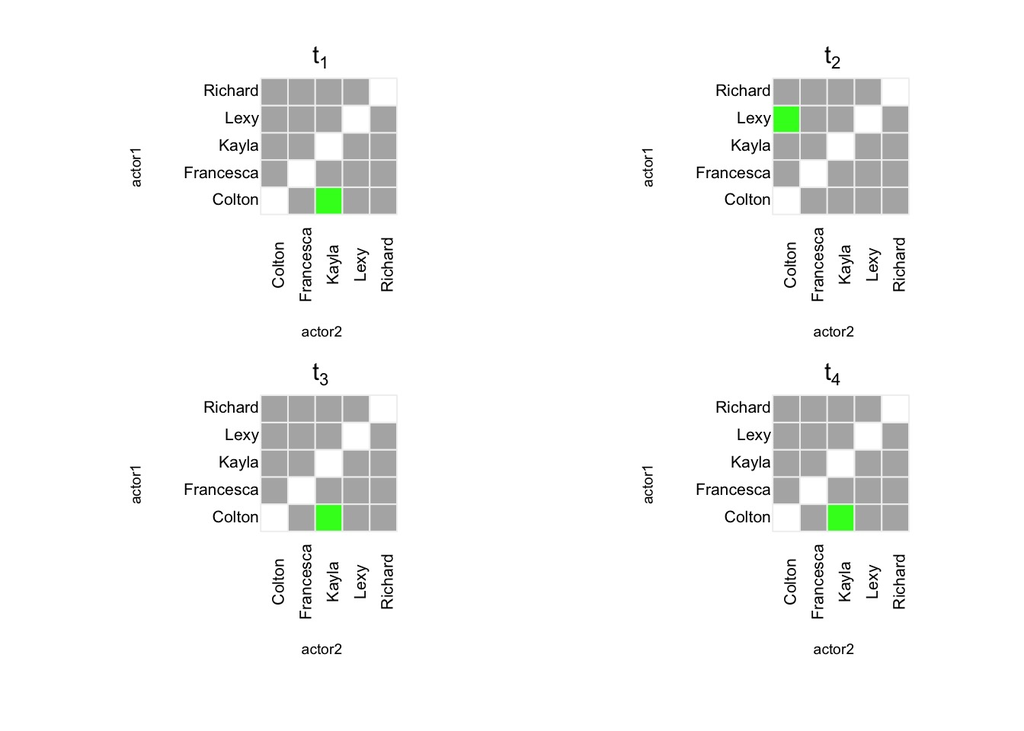

Considering the first four time points of `randomREHsmall`, we observe: the dyad *(Colton, Kayla)* at $t_1$, $t_3$, and $t_4$, and the dyad *(Lexy, Colton)* at $t_2$. Green cells mark observed events; gray cells mark other at-risk dyads; white cells mark infeasible events (self-loops).

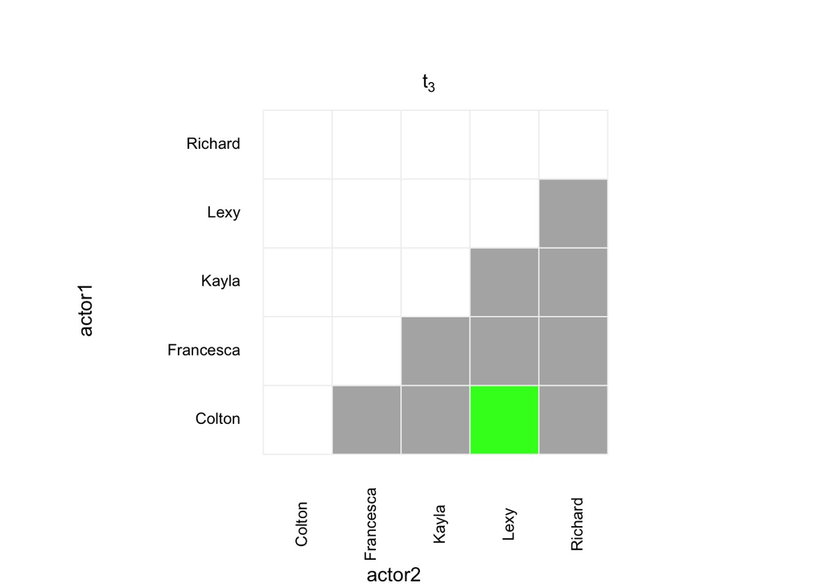

## The *active*, *active_saturated*, and *manual* risk set

The *full* risk set maintains a constant structure throughout the event history: all possible dyads are always at risk. Three alternative definitions accommodate settings where not all dyads are plausibly at risk.

### The *active* risk set

In sparse networks, the number of observed dyads can be far smaller than $D$. The *active* risk set restricts the risk set to only those dyads observed at least once in the event history, and maintains this structure throughout. Specify with `riskset = "active"`.

The use of the active risk set can substantially decrease computational time for both statistics and model estimation. However, this reduction excludes dyads that were never observed but might be plausibly at risk. It is good practice to examine the active dyads before proceeding and to consider whether the exclusion of unobserved dyads is defensible for the data at hand.

```r
reh_active <- remify(
  edgelist = randomREHsmall$edgelist,
  directed = TRUE,
  ordinal  = FALSE,
  model    = "tie",
  actors   = randomREHsmall$actors,
  riskset  = "active",
  origin   = randomREHsmall$origin
)

# number of dyads in full vs active risk set
reh_active$D
```

```
## [1] 20
```

```r
reh_active$activeD
```

```
## [1] 20
```

```r
# the active dyads
reh_active$riskset_info$included
```

```
##       actor1    actor2 dyadID actor1ID actor2ID
## 1     Colton Francesca      1        1        2
## 2     Colton     Kayla      2        1        3
## 3     Colton      Lexy      3        1        4
## 4     Colton   Richard      4        1        5
## 5  Francesca    Colton      5        2        1
## 6  Francesca     Kayla      6        2        3
## 7  Francesca      Lexy      7        2        4
## 8  Francesca   Richard      8        2        5
## 9      Kayla    Colton      9        3        1
## 10     Kayla Francesca     10        3        2
## 11     Kayla      Lexy     11        3        4
## 12     Kayla   Richard     12        3        5
## 13      Lexy    Colton     13        4        1
## 14      Lexy Francesca     14        4        2
## 15      Lexy     Kayla     15        4        3
## 16      Lexy   Richard     16        4        5
## 17   Richard    Colton     17        5        1
## 18   Richard Francesca     18        5        2
## 19   Richard     Kayla     19        5        3
## 20   Richard      Lexy     20        5        4
```

The grid visualization below shows the active risk set at time $t_3$. Only the dyads observed at least once in the history (gray and green tiles) are at risk; all other dyads are excluded (white tiles).

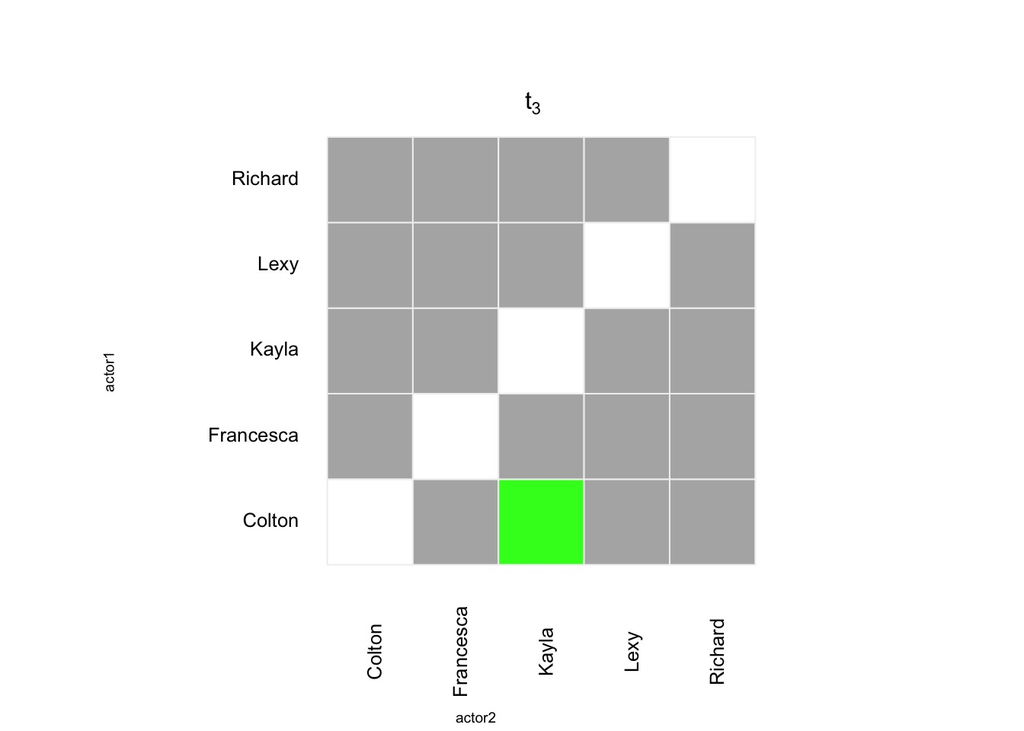

### The *active_saturated* risk set

The *active_saturated* risk set extends the active risk set by additionally including the reverse direction of each observed dyad and all event types for each observed actor pair. For instance, if A→B is observed, B→A is also included in the risk set. This reflects the assumption that observing an interaction between two actors implies that both directions (and all event types) are structurally possible, even if not yet observed. Specify with `riskset = "active_saturated"`.

```r
reh_sat <- remify(
  edgelist = randomREHsmall$edgelist,
  directed = TRUE,
  model    = "tie",
  riskset  = "active_saturated",
  actors   = randomREHsmall$actors,
  origin   = randomREHsmall$origin
)

reh_sat$activeD
```

```
## [1] 20
```

```r
reh_sat$riskset_info$included
```

```
##       actor1    actor2 dyadID actor1ID actor2ID
## 1     Colton Francesca      1        1        2
## 2     Colton     Kayla      2        1        3
## 3     Colton      Lexy      3        1        4
## 4     Colton   Richard      4        1        5
## 5  Francesca    Colton      5        2        1
## 6  Francesca     Kayla      6        2        3
## 7  Francesca      Lexy      7        2        4
## 8  Francesca   Richard      8        2        5
## 9      Kayla    Colton      9        3        1
## 10     Kayla Francesca     10        3        2
## 11     Kayla      Lexy     11        3        4
## 12     Kayla   Richard     12        3        5
## 13      Lexy    Colton     13        4        1
## 14      Lexy Francesca     14        4        2
## 15      Lexy     Kayla     15        4        3
## 16      Lexy   Richard     16        4        5
## 17   Richard    Colton     17        5        1
## 18   Richard Francesca     18        5        2
## 19   Richard     Kayla     19        5        3
## 20   Richard      Lexy     20        5        4
```

### The *manual* risk set

There are settings where only a specific, user-defined set of dyads should be considered at risk throughout the event history. This is the *manual* risk set, specified via `riskset = "manual"` and the `manual.riskset` argument.

`manual.riskset` is a `data.frame` with columns `actor1` and `actor2` (and optionally `type`) listing all dyads that are at risk. This defines a **static** risk set that does not vary over time. Any observed dyads from the edgelist that are absent from `manual.riskset` are added automatically with a warning.

Typical use cases include:

- **Structural constraints:** only certain actor pairs can interact (e.g., members of specific organizational units, or actors within each other’s contact list).
- **Sparse networks:** the user has domain knowledge about which dyads are plausibly at risk, beyond just those observed.
- **Spatial or group constraints:** only actors present in the same location or group can interact.

#### *Specifying a manual risk set*

```r
data(randomREH)

# Suppose we want to restrict the risk set to dyads among three actors only,
# while all other dyads are considered structurally impossible.
manual_rs <- data.frame(
  actor1 = c("Alexander", "Alexander", "Colton",    "Colton",    "Lexy",      "Lexy"),
  actor2 = c("Colton",    "Lexy",      "Alexander", "Lexy",      "Alexander", "Colton")
)

reh_manual <- remify(
  edgelist       = randomREH$edgelist,
  directed       = TRUE,
  ordinal        = FALSE,
  model          = "tie",
  actors         = randomREH$actors,
  riskset        = "manual",
  manual.riskset = manual_rs,
  origin         = randomREH$origin
)
```

```
## Note: `actors` is ignored when `riskset = "manual"` and `manual.riskset` is used
```

```r
# Active (manual) risk set size
reh_manual$activeD
```

```
## [1] 380
```

```r
# Inspect the decoded risk set
reh_manual$riskset_info$included
```

```
##        actor1    actor2 dyadID actor1ID actor2ID
## 1   Alexander    Andrey      1        1        2
## 2   Alexander   Breanna      2        1        3
## 3   Alexander   Charles      3        1        4
## 4   Alexander    Colton      4        1        5
## 5   Alexander   Crystal      5        1        6
## 6   Alexander     Derek      6        1        7
## 7   Alexander Francesca      7        1        8
## 8   Alexander    Justin      8        1        9
## 9   Alexander     Kayla      9        1       10
## 10  Alexander    Kelsey     10        1       11
## 11  Alexander   Kiffani     11        1       12
## 12  Alexander      Lexy     12        1       13
## 13  Alexander      Maya     13        1       14
## 14  Alexander   Mckenna     14        1       15
```

[output cut: 187 more lines]

Note that any observed event involving actor pairs outside `manual.riskset` will be automatically added to the risk set, ensuring that the likelihood is well-defined for all observed events.

The grid visualization below illustrates the manual risk set at time $t_3$, with dyads involving `"Richard"` and `"Francesca"` excluded (white tiles).

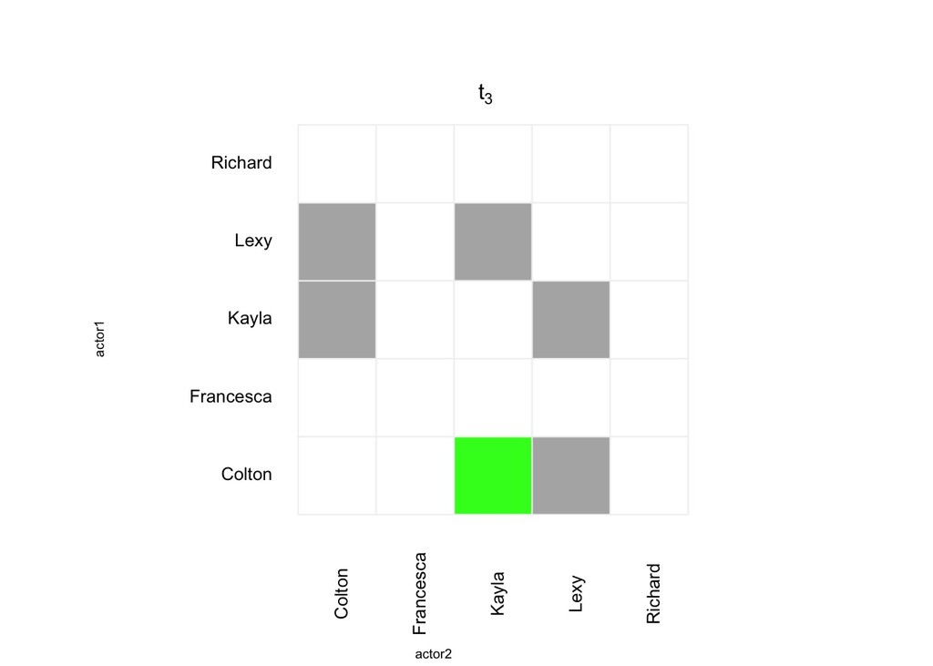

Here, tiles for dyads involving `"Richard"` and `"Francesca"` are white (excluded); the risk set contains only dyads among `"Colton"`, `"Kayla"`, and `"Lexy"`.

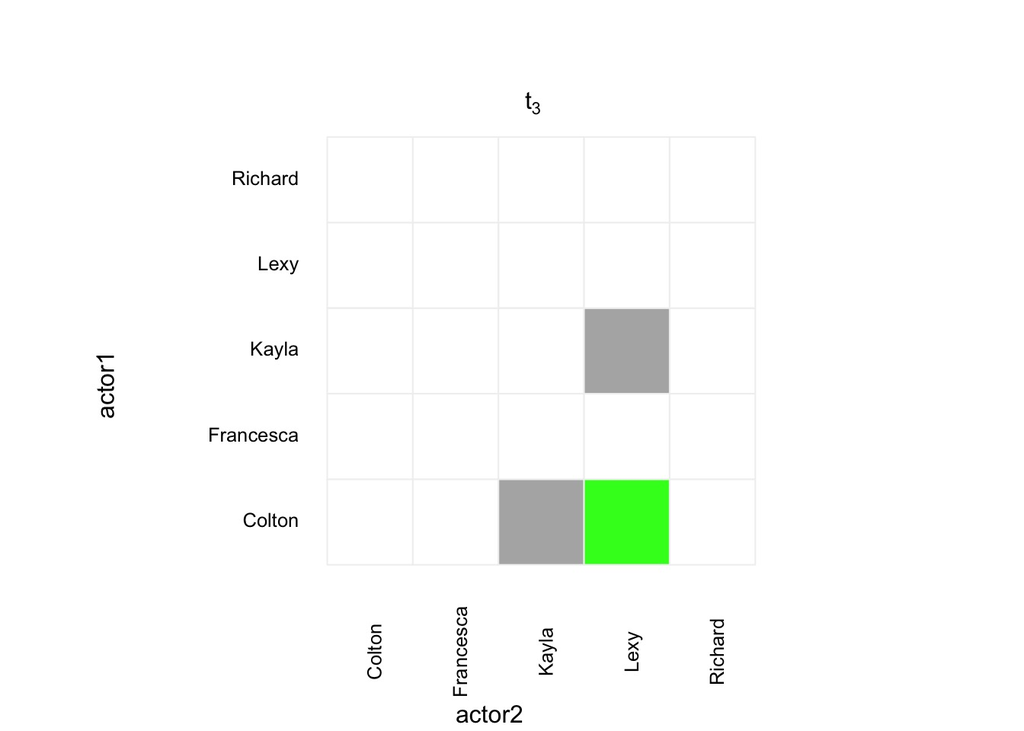

## The processed risk set

After processing, the `remify` object exposes the risk set through `riskset_info` (when `attach_riskset = TRUE`, which is the default). The key field is `riskset_info$included`, which contains the decoded table of at-risk dyads:

```r
reh_active <- remify(
  edgelist       = randomREH$edgelist,
  directed       = TRUE,
  ordinal        = FALSE,
  model          = "tie",
  actors         = randomREH$actors,
  riskset        = "active",
  origin         = randomREH$origin,
  riskset_decode = "labels"
)

head(reh_active$riskset_info$included)
```

```
##      actor1  actor2 dyadID actor1ID actor2ID
## 1 Alexander  Andrey      1        1        2
## 2 Alexander Breanna      2        1        3
## 3 Alexander Charles      3        1        4
## 4 Alexander  Colton      4        1        5
## 5 Alexander Crystal      5        1        6
## 6 Alexander   Derek      6        1        7
```

```r
nrow(reh_active$riskset_info$included) # number of active dyads
```

```
## [1] 380
```

For the full risk set, the dyad map is accessible directly via `reh$index$dyad_map`. For active or manual risk sets, it is in `reh$index$dyad_map_active`.

The per-event dyad IDs (mapping each observed event to its position in the risk set) are stored in `reh$ids$dyad`:

```r
# dyadID of the first 10 observed events
head(reh_active$ids$dyad, 10)
```

```
##  [1] 182  84 203   4 353 117 334 254 102  56
```

For actor-oriented modeling with an active or manual risk set, sender and receiver risk sets are stored in `reh$sender_riskset` and `reh$receiver_riskset` respectively, and `reh$index$sender_map` provides the mapping between sender IDs and actor names.